# *Python / Data Analysis Personal Project*

# 1. Introduction

This project explores the impact of natural disasters on human life from 1900 to 2025.  
Using global data from *Our World in Data*, the goal is to find out which disasters caused the highest number of deaths, how these numbers changed over time, and whether the number of disasters that resulted in fatalities has changed over time.

Understanding these long-term patterns helps us see not only how vulnerable humanity has been to natural forces, but also how progress in technology, communication, and preparedness may have changed the outcomes.

# 2. Research Questions

This project aims to investigate the human impact of natural disasters using global historical data from 1900 to 2025.  
The analysis focuses on the following key questions:

- Which type of natural disaster has caused the highest number of deaths globally?
- How have disaster-related deaths changed over time?
- What do these numbers represent when adjusted for the global population?

# 3. Data Cleaning and Preparation

The dataset used in this analysis comes from *Our World in Data* and contains global records of deaths caused by various types of natural disasters between **1900 and 2025**.  
It includes **7,718 rows** and **14 columns**, covering different disaster categories such as droughts, floods, earthquakes, volcanic activity, and others.

In this dataset, missing values in disaster-specific columns indicate no recorded deaths.  
Therefore, the `NaN` values were replaced with `0` to reflect this meaning and to make the dataset easier to interpret. As a result, subsequent counts of disasters reflect only occurrences that caused at least one death in a given country and year.

Additionally, the columns representing human deaths were converted from *float* to *integer* type to reflect the fact that deaths are whole numbers, which also reduces memory usage and improves clarity.

After these cleaning steps, the dataset is ready for exploratory data analysis.

|  | Entity | Code | Year | Droughts | Floods | Earthquakes | Storms | Extreme temperatures | Volcanoes | Wildfires | Glacial lake outbursts | Mass movements (dry) | Mass movements (wet) | Fogs |
| --- | --- | --- | --- | --- | --- | --- | --- | --- | --- | --- | --- | --- | --- | --- |
| 0 | Afghanistan | AFG | 1954 | NaN | NaN | 2000.0 | NaN | NaN | NaN | NaN | NaN | NaN | NaN | NaN |
| 1 | Afghanistan | AFG | 1956 | NaN | 51.0 | 100.0 | NaN | NaN | NaN | NaN | NaN | NaN | NaN | NaN |
| 2 | Afghanistan | AFG | 1963 | NaN | 107.0 | NaN | NaN | NaN | NaN | NaN | NaN | NaN | NaN | NaN |
| 3 | Afghanistan | AFG | 1969 | 0.0 | NaN | NaN | NaN | NaN | NaN | NaN | NaN | NaN | NaN | NaN |
| 4 | Afghanistan | AFG | 1971 | 0.0 | NaN | NaN | NaN | NaN | NaN | NaN | NaN | NaN | 100.0 | NaN |

|  | Year | Droughts | Floods | Earthquakes | Storms | Extreme temperatures | Volcanoes | Wildfires | Glacial lake outbursts | Mass movements (dry) | Mass movements (wet) | Fogs |
| --- | --- | --- | --- | --- | --- | --- | --- | --- | --- | --- | --- | --- |
| count | 7718.000000 | 2.061000e+03 | 4.315000e+03 | 2080.000000 | 3547.000000 | 1102.000000 | 654.000000 | 844.000000 | 26.000000 | 153.000000 | 1227.000000 | 4.0 |
| mean | 1988.288028 | 2.277398e+04 | 6.510832e+03 | 4705.887019 | 1608.898506 | 1582.533575 | 486.978593 | 25.337678 | 73.961538 | 117.699346 | 233.581092 | 4000.0 |
| std | 29.486726 | 1.906769e+05 | 1.195492e+05 | 22493.773099 | 13523.775623 | 8160.074336 | 3027.909539 | 78.255875 | 97.883392 | 321.190776 | 807.653452 | 0.0 |
| min | 1900.000000 | 0.000000e+00 | 0.000000e+00 | 0.000000 | 0.000000 | 0.000000 | 0.000000 | 0.000000 | 0.000000 | 0.000000 | 0.000000 | 4000.0 |
| 25% | 1973.000000 | 0.000000e+00 | 2.000000e+00 | 4.000000 | 2.000000 | 11.000000 | 0.000000 | 0.000000 | 3.500000 | 13.000000 | 21.000000 | 4000.0 |
| 50% | 1996.000000 | 0.000000e+00 | 2.200000e+01 | 50.000000 | 21.000000 | 80.500000 | 0.000000 | 3.000000 | 18.000000 | 44.000000 | 59.000000 | 4000.0 |
| 75% | 2011.000000 | 0.000000e+00 | 1.310000e+02 | 697.500000 | 204.500000 | 363.000000 | 37.000000 | 23.000000 | 178.000000 | 76.000000 | 183.500000 | 4000.0 |
| max | 2025.000000 | 3.000000e+06 | 3.700000e+06 | 277005.000000 | 304495.000000 | 74809.000000 | 38690.000000 | 1000.000000 | 250.000000 | 2000.000000 | 12000.000000 | 4000.0 |

```
<class 'pandas.core.frame.DataFrame'>
RangeIndex: 7718 entries, 0 to 7717
Data columns (total 14 columns):
 #   Column                  Non-Null Count  Dtype
---  ------                  --------------  -----
 0   Entity                  7718 non-null   object
 1   Code                    7718 non-null   object
 2   Year                    7718 non-null   int64
 3   Droughts                2061 non-null   float64
 4   Floods                  4315 non-null   float64
 5   Earthquakes             2080 non-null   float64
 6   Storms                  3547 non-null   float64
 7   Extreme temperatures    1102 non-null   float64
 8   Volcanoes               654 non-null    float64
 9   Wildfires               844 non-null    float64
 10  Glacial lake outbursts  26 non-null     float64
 11  Mass movements (dry)    153 non-null    float64
 12  Mass movements (wet)    1227 non-null   float64
 13  Fogs                    4 non-null      float64
dtypes: float64(11), int64(1), object(2)
memory usage: 844.3+ KB
```

# 4. Exploratory Data Analysis (EDA)

In this section, the dataset is explored to uncover patterns and insights about the human impact of natural disasters.  
The goal is to identify which disaster types have caused the most deaths, how their impact has evolved over time,  
and whether certain types of disasters resulting in deaths are becoming more or less frequent.

The analysis begins with a general overview of total deaths by disaster type, followed by a closer look at  
historical trends and long-term changes in individual disaster categories.

## 4.1 Overview of Total Deaths by Disaster Type

To understand which types of natural disasters have been the most deadly throughout history,  
the total number of deaths was calculated for each disaster type between 1900 and 2025.

This gives a high-level overview of which disasters have had the greatest human impact globally  
and serves as a foundation for more detailed trend analysis in the next sections.

[figure not shown]

The bar chart shows that **droughts and floods** have historically caused the highest number of deaths worldwide,  
far exceeding other types of natural disasters.  
These two categories dominate the global death toll, reflecting how vulnerable past societies were  
to food shortages and large-scale flooding events.

Other disasters, such as **earthquakes** and **extreme weather**, also caused significant loss of life,  
while **volcanic activity** and **wildfires** show relatively smaller global impact.

This overview suggests that while some disasters are rare, their consequences can be catastrophic —  
a topic explored in more detail in the following sections.

## 4.2 Overview of Disaster Frequency

The scatter and line plot provide an overall view of how the number of fatal disaster occurrences (i.e., disasters that caused at least one death) has changed over time. A clear turning point appears around 1960, after which the total number of recorded fatal events rises noticeably across most disaster types. The most significant growth is observed in floods and extreme weather, both showing a consistent upward trend likely linked to climate change and expanded reporting of disasters with fatalities.

Overall, the pattern suggests that disasters causing human deaths have become more frequent since the 1960s, but the total human impact varies depending on the type of hazard and the level of preparedness. These general trends will be explored in greater detail in the following sections, which focus on specific disaster types and their historical developments.

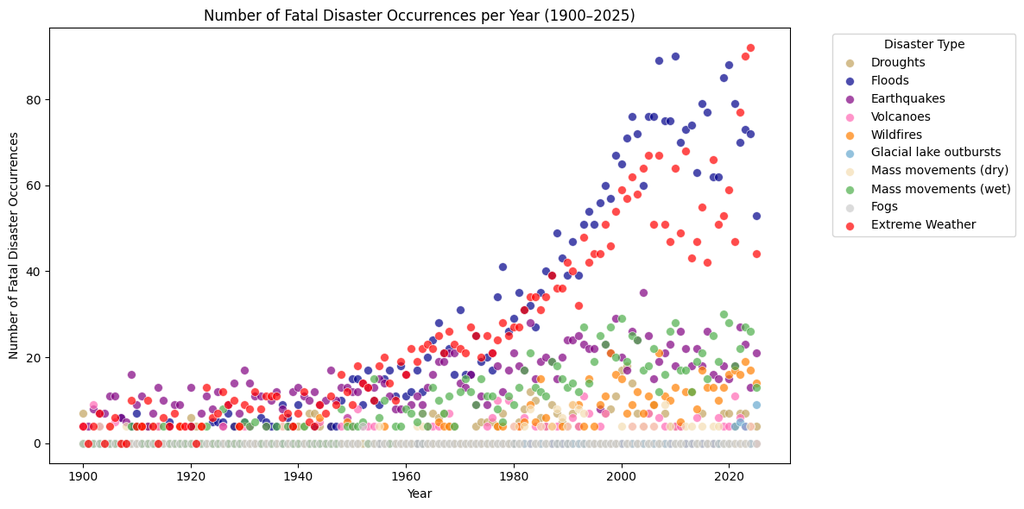

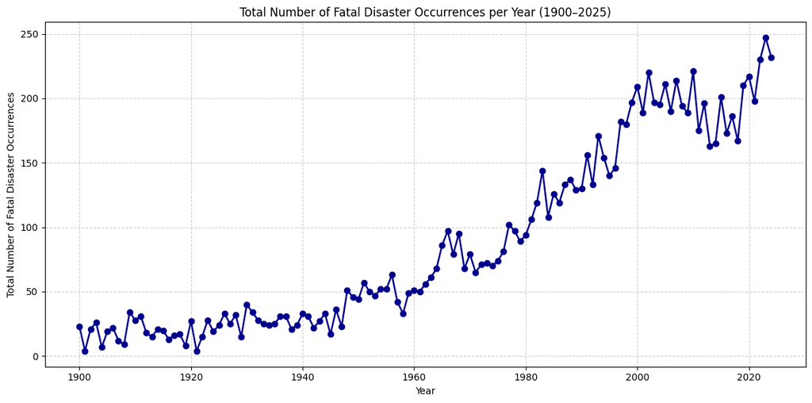

## 4.3 Droughts and Floods (1900 - 2025)

This section focuses on **droughts and floods**, the two disaster types that historically caused the highest number of deaths worldwide. To better understand their impact, two graphs are presented: a line chart showing the total number of deaths over time, and a scatter plot illustrating how frequently these disasters resulted in fatalities each year. Together, these visualizations reveal not only how deadly these events were, but also how their occurrence patterns have changed throughout history.

The analysis again uses 1960 as a dividing point, as earlier results indicated a clear shift in both the number of disaster events and total fatalities around that time.

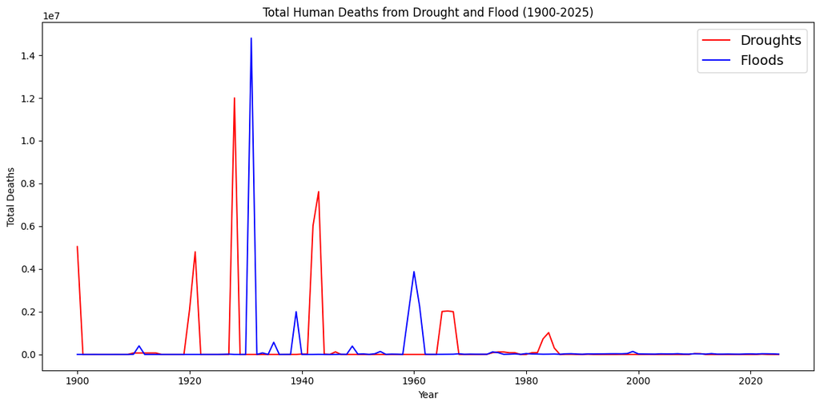

```
Deaths by Drought before 1960: 38080000
Deaths by Drought after 1960: 8857164
Deaths by Flood before 1960: 20461343
Deaths by Flood after 1960: 7632898
```

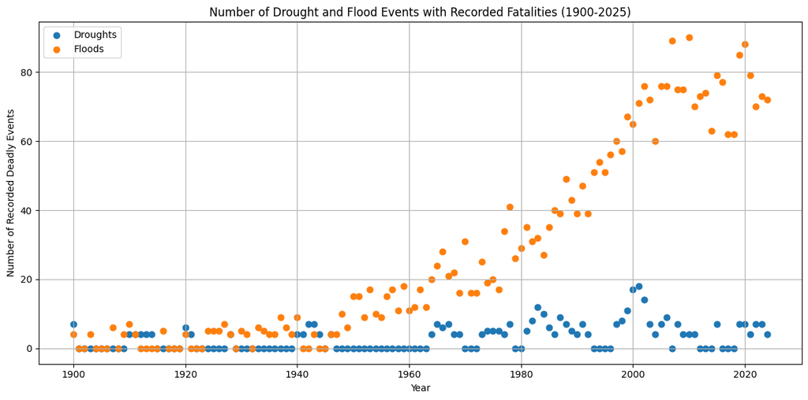

The scatter plot shows the number of drought and flood events that caused at least one death each year.

Overall, while the human toll of these disasters has fallen, the frequency of fatal events — especially floods — has risen sharply since the 1960s. This shift highlights the success of modern prevention systems, but also the continuing challenge of managing the increasing number of deadly weather-related disasters worldwide.

## 4.4 Extreme Weather and Earthquakes (1900–2025)

After examining floods and droughts, which dominated the early 20th century, this section focuses on **extreme weather and earthquakes** — two disaster types that have become increasingly relevant in recent decades.  
In the dataset, the original categories “Extreme temperatures” and “Storms” were combined into a single group called **Extreme Weather** to provide a clearer and more consistent overview of weather-related disasters.

The data were grouped by year to show how total deaths evolved between 1900 and 2025, again distinguishing the periods **before and after 1960**, when a clear shift in disaster patterns was observed. By comparing both the death tolls and event frequency, this section explores whether the modern rise in disasters also corresponds to greater human losses.

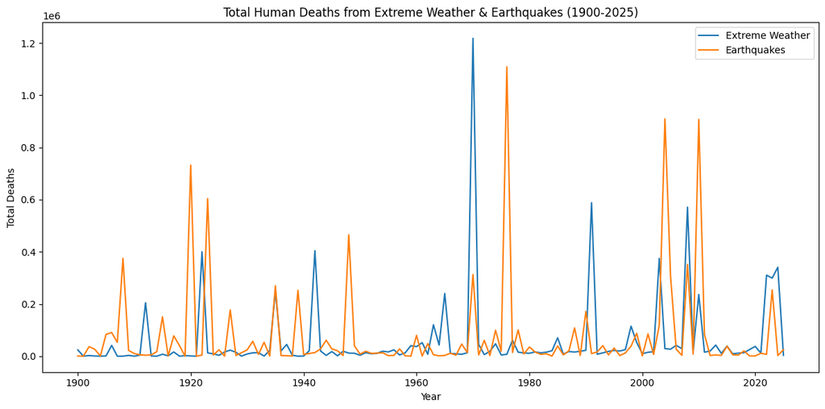

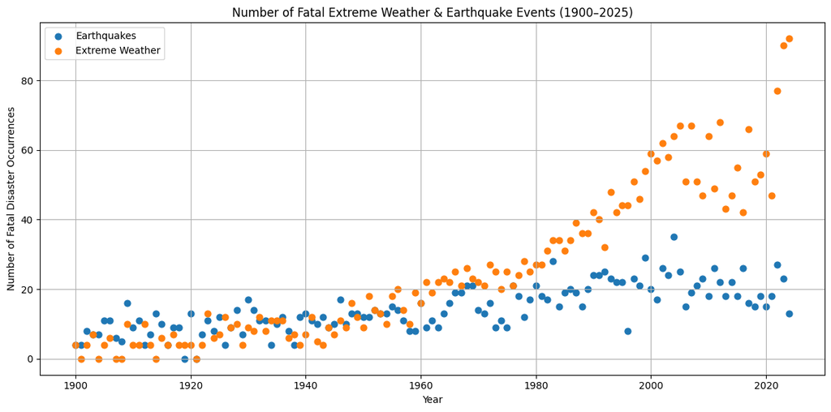

```
Deaths by Earthquakes before 1960: 4002260
Deaths by Earthquakes after 1960: 5785985
Deaths by Extreme Weather before 1960: 1829375
Deaths by Extreme Weather after 1960: 5621340
```

The chart shows that earthquakes and extreme weather both caused significant fatalities, but with different long-term patterns.

Overall, while preparedness and technology have limited the lethality of some disasters, the data reveal a clear shift toward more frequent **fatal climate-related events**, underlining the urgent need for continued global adaptation and resilience.

## 4.5 Volcanic Activity, Wildfires, and Wet Mass Movements (1900 - 2025)

This section focuses on volcanic activity, wildfires, and wet mass movements — disaster types that historically caused fewer deaths compared to floods or droughts. The section presents two graphs: a line chart showing total deaths per year and a scatter plot displaying the number of recorded fatal events annually between 1900 and 2025. Together, they highlight trends in the occurrence and mortality of these disasters over the past century, while noting that they remain less deadly overall than floods or droughts.

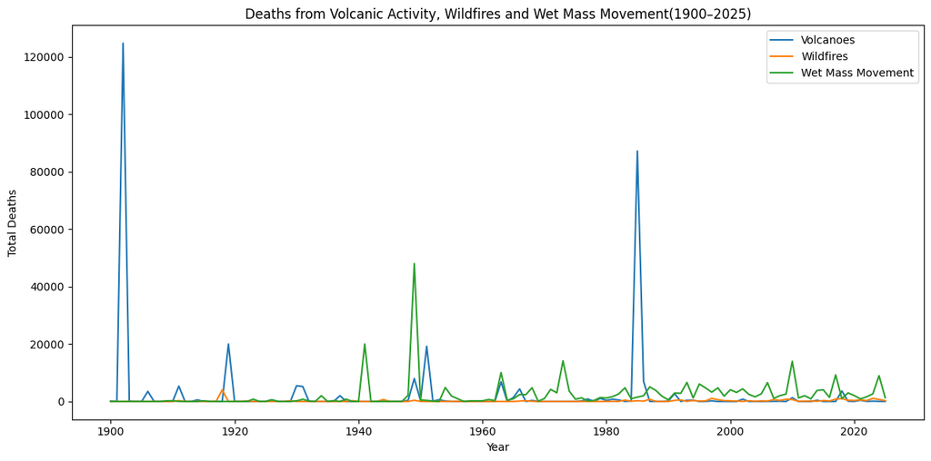

```
Deaths by Volcanic Activity before 1960: 196554
Deaths by Volcanic Activity after 1960: 121930
Deaths by Wildfire before 1960: 6112
Deaths by Wildfire after 1960: 15273
Deaths by Wet Mass Movement before 1960: 85486
Deaths by Wet Mass Movement after 1960: 201118
```

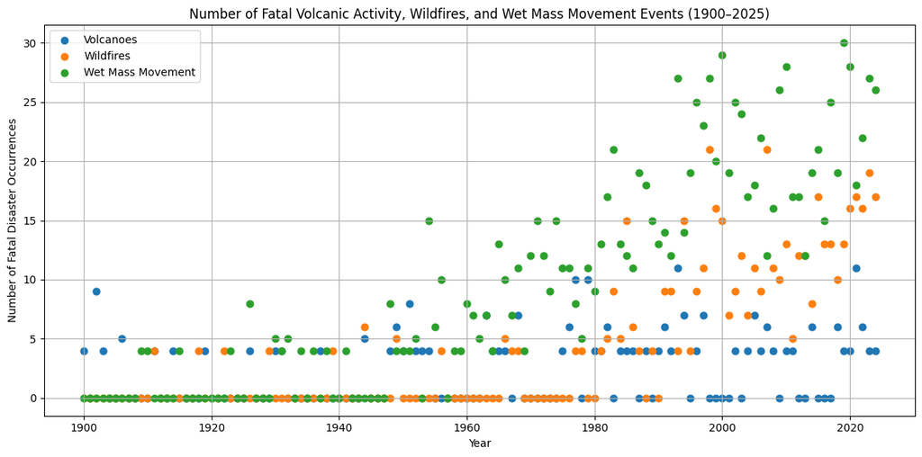

Overall, while fatalities remain relatively low compared to other disaster types, the increasing frequency of recorded fatal events highlights a shift toward more frequent deadly hazards in recent decades.

## 4.6 Deaths Relative to Global Population

To better understand the broader human impact of natural disasters, the total number of deaths was also compared to the size of the global population in each year between 1900 and 2025. This approach reveals how the proportion of people dying in disasters changed over time, rather than focusing only on absolute death counts.

The global population data were interpolated from historical estimates provided by the United Nations, and disaster-related deaths were expressed as a percentage of the total population for each year. Average percentages were then calculated for each decade to highlight long-term trends in humanity’s vulnerability to natural hazards.

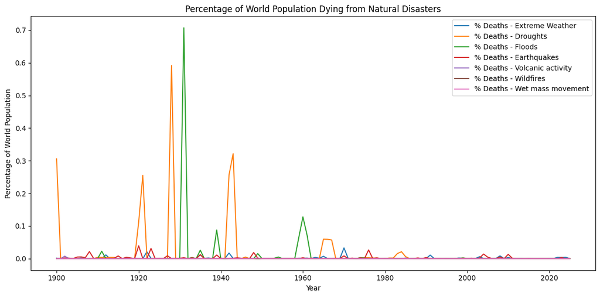

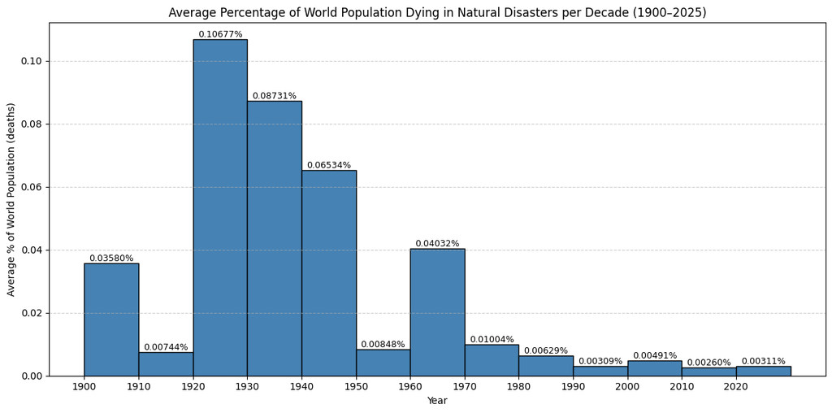

The results show a dramatic decline in the share of the global population dying from natural disasters over the past century. Between 1900 and 1960, disaster-related deaths often accounted for between **0.03% and 0.1% of the world’s population**, with the highest peaks occurring during the **1920s and 1930s** — decades marked not only by global conflict and famine but also by severe droughts and floods that devastated large regions.

After 1970, this proportion fell sharply, reaching **below 0.01%** in the modern era. This decline reflects major improvements in **food security, international aid, early warning systems, and disaster preparedness**, which have greatly reduced the lethality of natural hazards despite their increasing frequency.

While natural disasters continue to cause significant impacts worldwide, this analysis focuses solely on fatalities. The share of deaths relative to the world’s growing population has declined sharply. This trend suggests that although the number and intensity of disasters have increased, global population growth and improved disaster preparedness have prevented these events from causing a comparable rise in mortality.

# 5. Conclusion

This project explored the human impact of natural disasters from 1900 to 2025 using global historical data on events that caused at least one death. The analysis revealed that droughts and floods were the deadliest disasters of the early 20th century, responsible for tens of millions of deaths worldwide. Around 1960, a clear turning point emerged — the frequency of fatal natural disasters began to rise sharply, particularly for floods and extreme weather, yet the proportion of deaths relative to the world’s population declined dramatically.

These findings suggest that technological progress, improved disaster preparedness, and global cooperation have greatly reduced mortality from natural disasters, even as climate change has intensified weather extremes. Although such disasters continue to displace millions and cause substantial economic and environmental losses, humanity has become far more resilient to their fatal consequences.

Ultimately, the data highlight both the progress and the ongoing challenge: while the world is better equipped to save lives, reducing the broader human and environmental costs of natural disasters remains one of the defining goals of the 21st century.

|  | Disaster Type | Total Deaths | Deaths before 1960 | Deaths after 1960 | Average % of World Population | Trend Sumary |
| --- | --- | --- | --- | --- | --- | --- |
| 0 | Droughts | 46,937,164 | 38,080,000 | 8,857,164 | 0.016709 | Sharp decline in deaths over time |
| 1 | Floods | 28,094,241 | 20,461,343 | 7,632,898 | 0.009266 | Decline in deaths after 1960 |
| 2 | Earthquakes | 9,788,245 | 4,002,260 | 5,785,985 | 0.002456 | Moderate increase in deaths after 1960 |
| 3 | Extreme Weather | 7,450,715 | 1,829,375 | 5,621,340 | 0.001569 | Strong increase in deaths after 1960 |
| 4 | Volcanoes | 318,484 | 196,554 | 121,930 | 0.000107 | Irregular peaks with low overall deaths |
| 5 | Wet Mass Movement | 286,604 | 85,486 | 201,118 | 0.000058 | Rising deaths after 1960, irregular pattern |
| 6 | Wildfires | 21,385 | 6,112 | 15,273 | 0.000004 | Slight increase in deaths after 1960 |

# 6. References

Data sources: EM-DAT, CRED / UCLouvain – processed by Our World in Data. “Number of deaths from disasters” [dataset]. EM-DAT, CRED / UCLouvain [original data].

https://ourworldindata.org/natural-disasters

Data included up to: October 2025  
Analysis / processing completed: March 2026

### Category Definitions (EM-DAT / Our World in Data)

- **Drought:** Extended period of abnormally low precipitation causing water shortage for people, animals, and plants.
- **Flood:** Overflow of water onto normally dry land, including riverine, flash, coastal, and reservoir flooding.
- **Extreme Weather:** Tropical cyclones, hurricanes, typhoons, storms, tornadoes, hailstorms, and other severe weather events.
- **Extreme Temperature:** Periods of unusually high or low temperatures, such as heatwaves or cold waves.
- **Earthquake:** Sudden movement of the Earth’s crust along a fault, including impacts from aftershocks and tsunamis.
- **Volcanic Activity:** Eruptions or events involving lava, ash, gases, or pyroclastic material near volcanic vents.
- **Wildfire:** Uncontrolled fire in forests, grasslands, or other natural areas, often driven by wind and terrain.
- **Mass Movement (Dry/Wet):** Downslope movement of earth materials. Dry types occur without water, while wet types (landslides, mudslides) are triggered by heavy rain or snowmelt.
- **Glacial Lake Outburst Flood (GLOF):** Sudden release of water held by a glacier or moraine, causing rapid downstream flooding.
- **Fog:** Suspension of water droplets near the ground reducing visibility — only one major event recorded (London Smog, 1952).